# TOTVS Challenge

### 1. Parse and extract the data

Running the script found in “scripts/data_loader.py” will parse, extract and load the data into a relational postgres database.

#### Reading data from database

```r
# runs a script contain the username and password for the database
source("../scripts/my_pass.r")

# loads the PostgreSQL driver
drv <- dbDriver("PostgreSQL")

# creates a connection to the postgres database
con <- dbConnect(drv, dbname = "postgres",
                 host = "localhost", port = 5432,
                 user = username, password = pw)

# query daily sales
query <- "select date_str, sum(units * sales.unit_price) as revenue  from totvs.sales GROUP BY date_str;"
sales <- dbGetQuery(con, query)

# query daily sales per product
query <- "select product, date_str, sum(units) as units, sum(units * sales.unit_price) as revenue  from totvs.sales GROUP BY product, date_str;"
prod_sales <- dbGetQuery(con, query)

# query total sales per product per price
query <- "select product, unit_price, sum(units) as units from totvs.sales GROUP BY product, unit_price;"
price_sales <- dbGetQuery(con, query)

# Removing variables
rm(con,drv,pw,username,query)
```

#### Data Treatment

```r
sales$date_order <- as.Date(sales$date_str)
prod_sales$date_order <- as.Date(prod_sales$date_str)

sales$day_week <- wday(sales$date_order, label = TRUE, abbr = TRUE)
prod_sales$day_week <- wday(prod_sales$date_order, label = TRUE, abbr = TRUE)
```

### 2. Identify a pattern on any set of fields that can help predict how much a customer will spend.

#### Impact of day of the week in sales

It’s known that the day of the week has a major impact on sales across multiple industries. In this restaurant it’s not different and the bar plot below depicts just that.

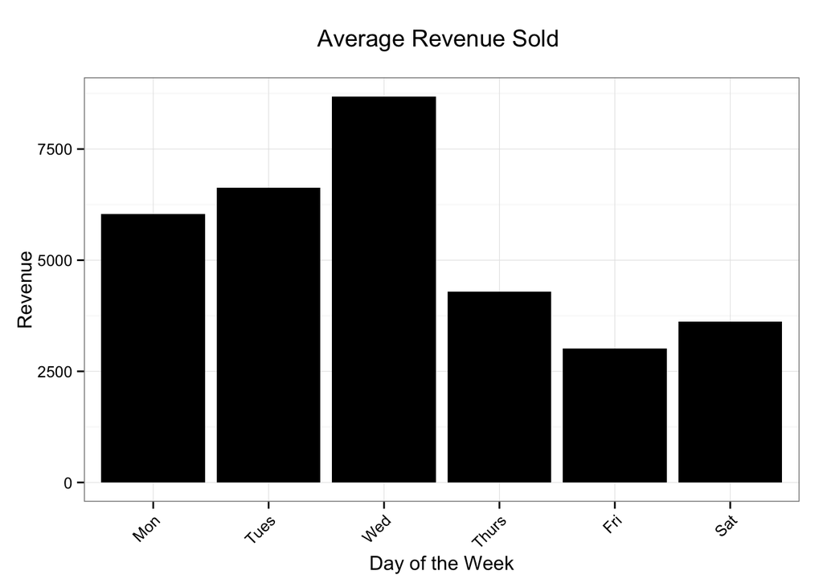

```r
weekday_sales <- aggregate(x = list(revenue = sales$revenue),
                           by = list(day_week = sales$day_week),
                           FUN = mean, na.rm = TRUE)

my_title <-"Average Revenue Sold \n"
p <- ggplot(weekday_sales, aes(day_week, revenue)) + theme_bw()
p <- p + geom_bar(fill = "black", stat = "identity")
p <- p + labs(title = my_title, x = "Day of the Week", y = "Revenue")
p <- p + theme(axis.text.x = element_text(angle = 45, vjust = 1, hjust=1))
p
```

#### Price Elasticity

The idea here is to see how the price impacts the sales of each product. Because many products did not change prices, most plots are not informative.

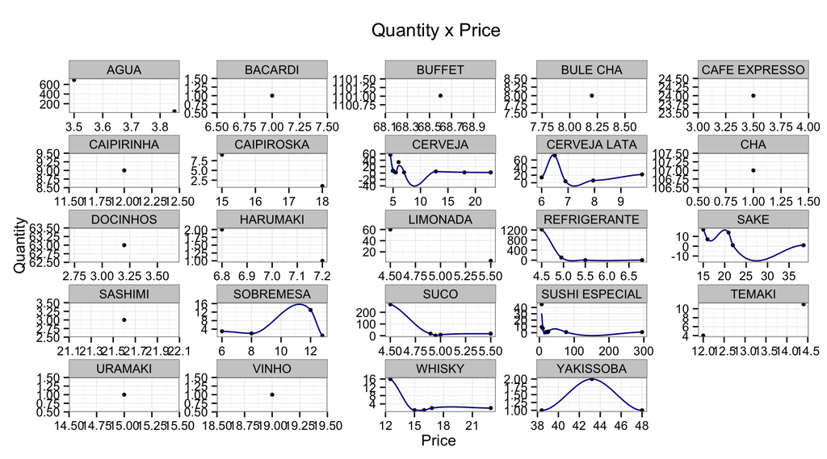

```r
p <- ggplot(price_sales, aes(unit_price, units)) + geom_point(size = 1.5)
p <- p + theme_bw()
p <- p + labs(title = "Quantity x Price \n", x = "Price", y = "Quantity")
p <- p + facet_wrap(~product, scales = "free")
p <- p + geom_smooth(se = FALSE, colour = plot_color)
p
```

## 3. Calculate a sales forecast for the next week.

### Time Series

This is the Daily Revenue over time.

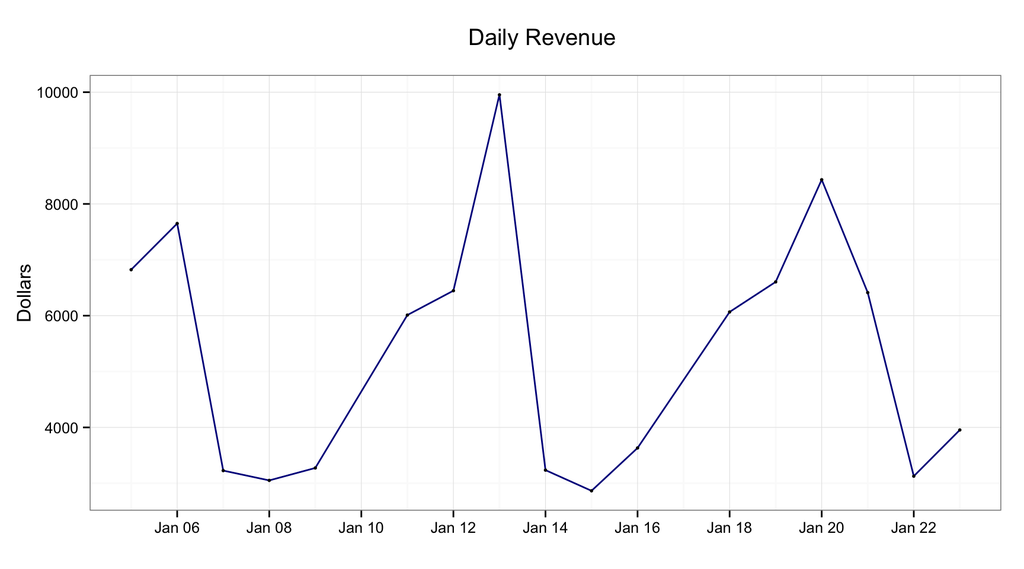

```r
p <- ggplot(sales, aes(date_order, revenue))
p <- p + geom_line(colour = plot_color) + geom_point(colour ="black", size = 1)
p <- p + labs(title = "Daily Revenue \n", x = "", y = "Dollars")
p <- p + theme_bw()
p
```

In this plot I broke down the revenue per product. With more time I would group some of them into categories and then do the forecast for each group. Another issue is the lack of data for certain products. With more data I could even have a prediction per product, although I still believe grouping them into categories would yield a better result.

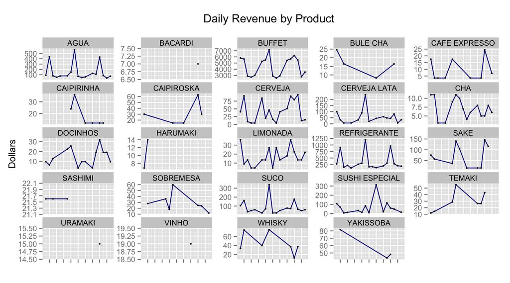

```r
# Daily revenue per product
p <- ggplot(prod_sales, aes(date_order, revenue))
p <- p + geom_line(colour = plot_color) + geom_point(colour ="black", size = 1)
p <- p + labs(title = "Daily Revenue by Product \n", x = "", y = "Dollars")
p <- p + theme(axis.text.x=element_blank()) + facet_wrap(~product, scales = "free_y")
p
```

### Model Selection

```r
library("tseries")
my_ts <- ts(sales[order(sales$date_order),"revenue"])
```

Checking for stationarity

```r
adf.test(my_ts, k=2)
```

```
##
##  Augmented Dickey-Fuller Test
##
## data:  my_ts
## Dickey-Fuller = -4.6061, Lag order = 2, p-value = 0.01
## alternative hypothesis: stationary
```

The test indicates the time series is stationary, so there is no need for differencing.

ACF and PACF plots

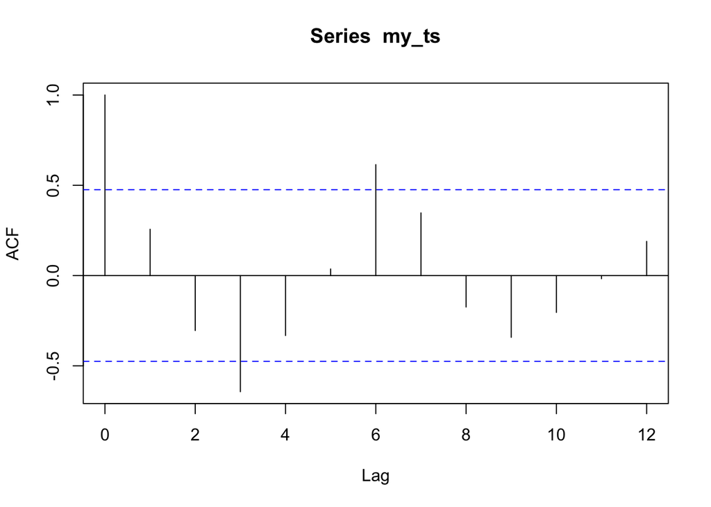

```r
acf(my_ts)
```

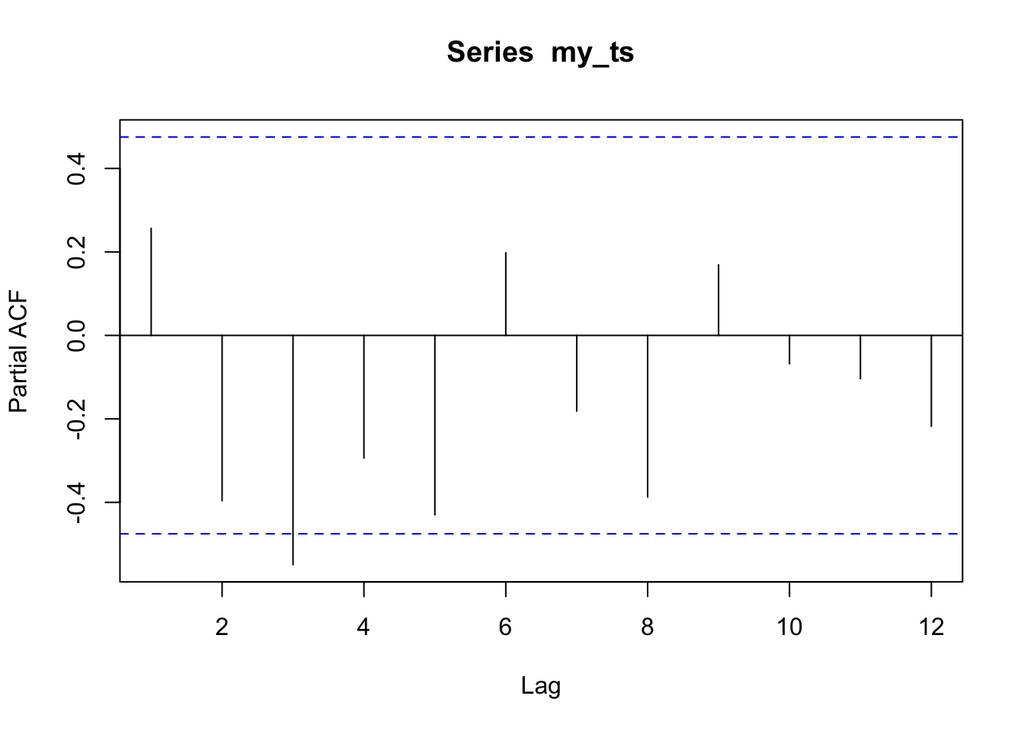

```r
pacf(my_ts)
```

The seasonality of 6 days was more than expected. We will remove the seasonal component and then check the ACF and PACF again.

```r
dmy_ts <- diff(my_ts, lag = 6)
adf.test(dmy_ts)
```

```
##
##  Augmented Dickey-Fuller Test
##
## data:  dmy_ts
## Dickey-Fuller = -1.2821, Lag order = 2, p-value = 0.8459
## alternative hypothesis: stationary
```

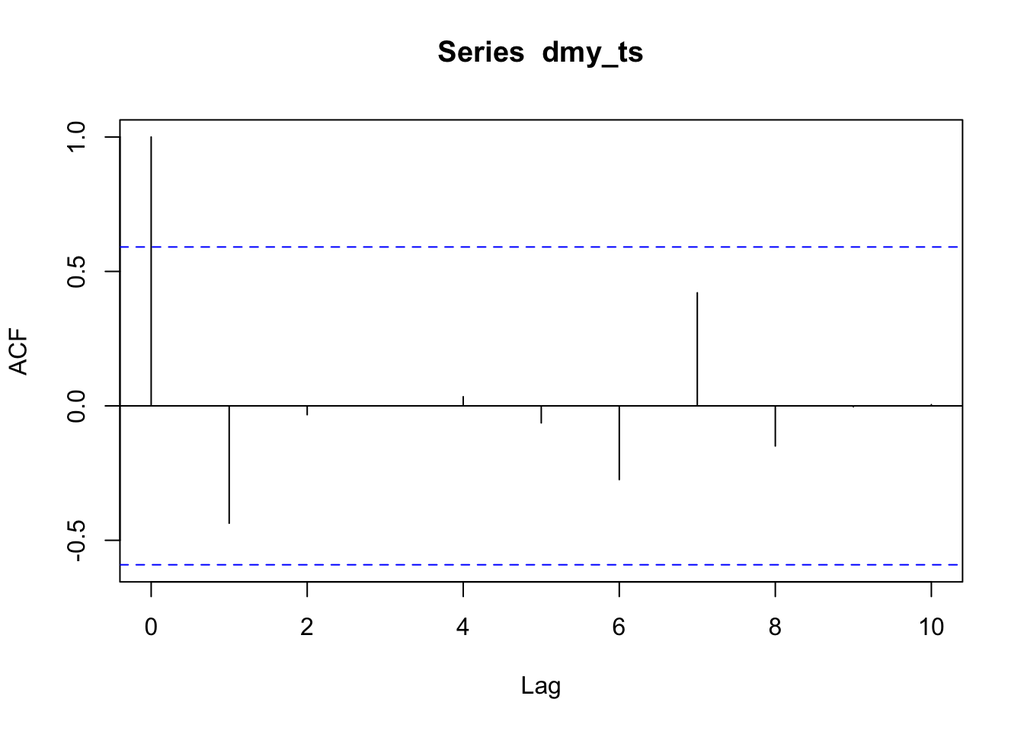

```r
acf(dmy_ts)
```

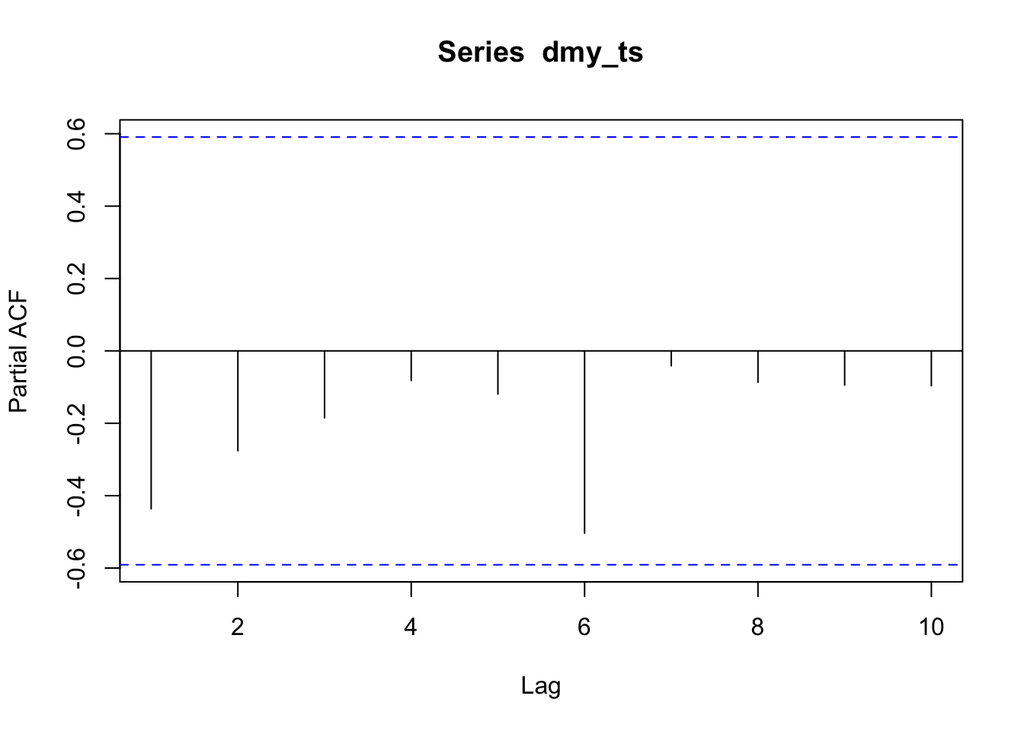

```r
pacf(dmy_ts)
```

After removing seasonality there is no statistically significant auto-regressive or moving averages component.

#### Fitting Model

```r
my_model <- arima(my_ts, order = c(0,0,0), seasonal = list(order = c(0,1,1), period = 6))
```

#### Normality check

```r
e <- my_model$residuals
shapiro.test(e)
```

```
##
##  Shapiro-Wilk normality test
##
## data:  e
## W = 0.63991, p-value = 2.602e-05
```

#### Autocorrelation

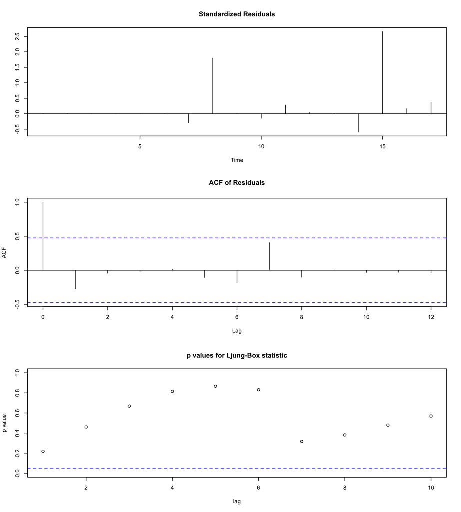

#### Forecast for next week

```r
forecast <- predict(my_model, n.ahead = 6, plot = T, conf = 0.95)
```

#### Plotting Forecast

```r
pred_days <- seq(as.Date("2016-01-25"), as.Date("2016-01-30"), by="days")
pred_revenue <- forecast$pred
sales$type <- "real_data"
pred <- data.frame(date_order = pred_days, revenue = pred_revenue, type = "prediction")

df <- rbind(sales[,c("date_order","revenue","type")], pred)
```

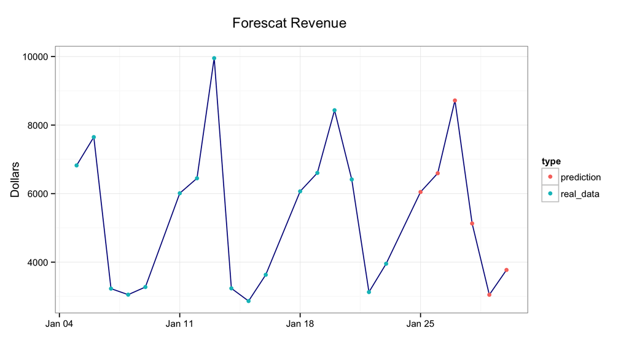

```r
# Daily revenue
p <- ggplot(df, aes(date_order, revenue))
p <- p + geom_line(colour = plot_color) + geom_point(aes(colour = type), size = 2)
p <- p + labs(title = "Forescat Revenue \n", x = "", y = "Dollars")
p <- p + theme_bw()
p
```

Total Revenue for next week in [Reais]

```r
sum(forecast$pred)
```

```
## [1] 33309.21
```